# Mini Proyecto 2

## Alcanzando los Objetivos de Desarrollo Sostenible: clasificación automática de textos

**Curso:** Machine Learning No Supervisado **Programa:** Maestría en Inteligencia Artificial — Semestre 2

### Integrantes

- Juan Avendaño García
- Leonardo Cano Uribe

**Fecha:** Septiembre de 2026

# Contenido

0. Planteamiento del proyecto
1. Conjunto de datos
   - 1.1 Fuente y naturaleza · 1.2 Configuración · 1.3 Carga
   - 1.4 Distribución por ODS · 1.5 Longitud de los textos · 1.6 Partición
2. Preparación del texto y pipeline
   - 2.1 Decisiones de preparación · 2.2 BOW y TF-IDF · 2.3 Normalizador
   - 2.4 Pipeline · 2.5 Verificación
3. Modelo LSA y tópicos
   - 3.1 Qué es LSA · 3.2 Número de componentes · 3.3 Extracción de tópicos
   - 3.4 Interpretación frente a los ODS · 3.5 Espacio latente
4. Reducción de dimensionalidad para clasificar
   - 4.1 Por qué reducir · 4.2 Las dos representaciones
5. Modelo de clasificación
   - 5.1 Algoritmos · 5.2 Métricas · 5.3 Validación
   - 5.4 Búsqueda de hiperparámetros · 5.5 TF-IDF frente a LSA · 5.6 Modelo final
6. Evaluación sobre el conjunto de test
   - 6.1 Métricas globales · 6.2 Reporte por clase · 6.3 Matriz de confusión
   - 6.4 Clasificación de textos concretos · 6.5 Análisis de errores
7. Conclusiones
8. Clasificación de textos nuevos
9. Bono: aplicación web
10. Declaración de uso de IA generativa

# 0. Planteamiento del proyecto

## Contexto

En septiembre de 2015 la ONU adoptó la **Agenda 2030 para el Desarrollo Sostenible**, que define **17 Objetivos de Desarrollo Sostenible (ODS)** y 169 metas derivadas. Su seguimiento exige evaluar continuamente políticas públicas y su impacto social.

El **Fondo de Población de las Naciones Unidas (UNFPA)**, junto con instituciones públicas, recoge información mediante herramientas de participación ciudadana y necesita relacionarla con los ODS. Ese paso es hoy el cuello de botella: **interpretar y clasificar textos a mano consume muchísimos recursos y requiere expertos** que conozcan los 17 objetivos. Mientras tanto, la opinión de la población no llega a tiempo a la toma de decisiones.

## El problema

Dado un texto en lenguaje natural —una propuesta ciudadana, un fragmento de un informe, el resumen de un artículo—, **determinar automáticamente a qué Objetivo de Desarrollo Sostenible corresponde**.

Es un problema de clasificación supervisada, pero su dificultad está en la **representación**: un texto no es un vector de números. Hay que convertir lenguaje en algo que un algoritmo pueda medir, sin perder la evidencia léxica que distingue un objetivo de otro, y sin que la dimensionalidad se dispare hasta hacer inviable el aprendizaje.

Ahí es donde entran las técnicas no supervisadas de la asignatura: **TF-IDF** para ponderar la importancia de cada término y **LSA** (análisis semántico latente, mediante SVD truncado) para descubrir los conceptos que subyacen al vocabulario y comprimir el espacio de entrada.

## Objetivos

### Objetivo general

Desarrollar una solución basada en procesamiento de lenguaje natural y machine learning que clasifique automáticamente un texto según los Objetivos de Desarrollo Sostenible, justificando cada decisión de diseño.

### Objetivos específicos

1. Construir un *pipeline* reproducible que transforme texto en español en una matriz TF-IDF, documentando cada transformación aplicada.
2. Obtener un modelo de tópicos mediante SVD truncado sobre esa matriz e interpretar cualitativamente si las componentes latentes guardan relación con los ODS.
3. Comparar tres algoritmos de clasificación con búsqueda de hiperparámetros, validándolos con métricas adecuadas a un problema desbalanceado.
4. Medir qué aporta y qué cuesta la reducción de la dimensionalidad, contrastando el rendimiento sobre TF-IDF crudo frente al espacio LSA.
5. Evidenciar el desempeño sobre textos que no participaron en el aprendizaje.

## Esquema del método

```
                    ┌──────────────────── Pipeline de scikit-learn ────────────────────┐

   texto       →    normalización      →    TF-IDF      →    LSA          →   clasificador  →  ODS
   crudo            minúsculas              BOW con          SVD truncado      SVM lineal
                    sin acentos             pesado           + Normalizer      Reg. logística
                    sin dígitos             TF-IDF                             Random Forest
                    stopwords               1-2 gramas       (n componentes
                    stemming                                  = hiperparámetro)
                                                 │
                                                 └──→  §3  tópicos latentes  →  interpretación
                                                            frente a los ODS
```

# 1. Conjunto de datos

## 1.1 Fuente y naturaleza de los datos

Los textos provienen del **OSDG Community Dataset (OSDG-CD)**, versión 2023, un proyecto que reúne investigadores y especialistas en desarrollo sostenible de todo el mundo. Su corpus completo tiene 40.067 textos —documentos públicos, resúmenes de artículos e informes, 3.000 de ellos de fuentes de Naciones Unidas—, etiquetados por voluntarios que validan la relevancia de cada texto frente a los ODS a partir de su conocimiento experto.

Para este proyecto se trabaja con un subconjunto **traducido al español con DeepL** y **aumentado mediante la API de ChatGPT**. Esta procedencia tiene dos consecuencias que conviene tener presentes desde el principio, porque afectan a cómo hay que leer los resultados:

- **La traducción automática introduce sesgo léxico.** DeepL tiende a elegir sistemáticamente la misma traducción para un término, de modo que el vocabulario resultante es más uniforme que el de un corpus escrito originalmente en español.
- **La aumentación puede generar textos emparentados.** Si varias entradas derivan de un mismo original, podrían repartirse entre entrenamiento y test, y el modelo estaría siendo evaluado sobre variantes de lo que ya vio.

## 1.2 Configuración: librerías y semilla global

Todas las importaciones se concentran en una celda para que las dependencias del método queden explícitas en un solo lugar.

Se define una **semilla global** que se propaga a todo proceso con componente aleatoria: la partición estratificada, la inicialización del SVD truncado, el Random Forest y la validación cruzada. Sin ella los resultados cambiarían en cada ejecución y las comparaciones entre modelos no serían fiables.

El corpus de *stopwords* de NLTK viaja en la carpeta `nltk_data/` del repositorio, de modo que el notebook **no necesita conexión a Internet**: se antepone esa ruta a `nltk.data.path` en lugar de llamar a `nltk.download()` en tiempo de ejecución.

```python
# Configuracion global del notebook: importaciones, semilla y constantes.

import os
import re
import time
import string
import unicodedata
import warnings

import numpy as np
import pandas as pd

import matplotlib.pyplot as plt
from matplotlib.lines import Line2D

import seaborn as sns

import nltk
# El corpus viaja en el repositorio: se antepone para no depender de la red.
nltk.data.path.insert(0, "nltk_data")
from nltk.corpus import stopwords
from nltk.stem import SnowballStemmer

from sklearn.base import BaseEstimator, TransformerMixin, clone
from sklearn.utils.validation import check_is_fitted
from sklearn.pipeline import Pipeline
from sklearn.feature_extraction.text import TfidfVectorizer
from sklearn.decomposition import TruncatedSVD
from sklearn.preprocessing import Normalizer
from sklearn.model_selection import (
    train_test_split,
    StratifiedKFold,
    GridSearchCV,
)
from sklearn.svm import LinearSVC
from sklearn.linear_model import LogisticRegression
from sklearn.ensemble import RandomForestClassifier
from sklearn.metrics import (
    f1_score,
    accuracy_score,
    balanced_accuracy_score,
    classification_report,
    confusion_matrix,
)

# Semilla unica para todo el notebook.
SEMILLA = 42
np.random.seed(SEMILLA)

# Parametros del metodo.
RUTA_DATOS = os.path.join("data", "Datos_textosODS.xlsx")
PROPORCION_TEST = 0.20
N_COMPONENTES_TOPICOS = 15
N_PLIEGUES = 5

# Nombres oficiales de los 17 ODS, para rotular figuras e interpretar topicos.
NOMBRES_ODS = {
    1:  "Fin de la pobreza",
    2:  "Hambre cero",
    3:  "Salud y bienestar",
    4:  "Educacion de calidad",
    5:  "Igualdad de genero",
    6:  "Agua limpia y saneamiento",
    7:  "Energia asequible y no contaminante",
    8:  "Trabajo decente y crecimiento economico",
    9:  "Industria, innovacion e infraestructura",
    10: "Reduccion de las desigualdades",
    11: "Ciudades y comunidades sostenibles",
    12: "Produccion y consumo responsables",
    13: "Accion por el clima",
    14: "Vida submarina",
    15: "Vida de ecosistemas terrestres",
    16: "Paz, justicia e instituciones solidas",
    17: "Alianzas para lograr los objetivos",
}

pd.set_option("display.max_columns", 40)
pd.set_option("display.width", 160)
sns.set_theme(style="whitegrid")
warnings.filterwarnings("ignore", category=FutureWarning)

print(f"pandas {pd.__version__} | numpy {np.__version__} | nltk {nltk.__version__}")
print(f"Semilla global: {SEMILLA}")
print(f"Stopwords en espanol disponibles: {len(stopwords.words('spanish'))}")
```

```
pandas 3.0.5 | numpy 2.5.2 | nltk 3.10.3
Semilla global: 42
Stopwords en espanol disponibles: 313
```

## 1.3 Carga del conjunto de datos

El archivo contiene una sola hoja con dos columnas: `textos`, con el texto en español, y `ODS`, con el número de objetivo asignado por los anotadores.

```python
# Lectura y validacion del conjunto de datos.

def cargar_dataset(ruta=RUTA_DATOS):
    """Lee el archivo de textos etiquetados y valida su estructura.

    Parametros
    ----------
    ruta : str
        Ruta del archivo .xlsx con las columnas 'textos' y 'ODS'.

    Retorna
    -------
    pd.DataFrame
        Columnas 'texto' (str), 'ods' (int) y 'n_palabras' (int).
    """
    df = pd.read_excel(ruta)

    faltantes = {"textos", "ODS"} - set(df.columns)
    if faltantes:
        raise ValueError(
            f"El archivo no tienen las columnas: {sorted(faltantes)}. "
            f"Encontradas: {list(df.columns)}"
                        )

    df = df.rename(columns={"textos": "texto", "ODS": "ods"})

    n_inicial = len(df)
    texto_vacio = df["texto"].fillna("").astype(str).str.strip() == ""
    df = df[~texto_vacio & df["ods"].notna()].copy()

    if n_inicial > len(df):
        print(f"Se eliminaron {n_inicial - len(df)} filas con texto vacio o etiqueta nula.")

    ods = pd.to_numeric(df["ods"], errors="coerce")
    if ods.isna().any():
        valores = df.loc[ods.isna(), "ods"].unique()
        raise ValueError(f"Valores de ODS no convertibles a int: {valores[:5]}")

    df["ods"] = ods.astype(int)

    fuera = df.loc[~df["ods"].between(1, 17), "ods"].unique()
    if len(fuera) > 0:
        raise ValueError(f"Valores de ODS fuera del rango 1-17: {sorted(fuera)}")

    df["texto"] = df["texto"].astype(str).str.strip()
    df["n_palabras"] = df["texto"].str.split().str.len()

    return df.reset_index(drop=True)


datos = cargar_dataset()

print(f"Textos            : {len(datos):,}")
print(f"ODS distintos     : {datos['ods'].nunique()}")
print(f"Duplicados exactos: {datos['texto'].duplicated().sum()}")
datos.head(3)
```

```
Textos            : 9,656
ODS distintos     : 16
Duplicados exactos: 0
```

|  | texto | ods | n_palabras |
| --- | --- | --- | --- |
| 0 | "Aprendizaje" y "educación" se consideran sinó... | 4 | 48 |
| 1 | No dejar clara la naturaleza de estos riesgos ... | 6 | 156 |
| 2 | Como resultado, un mayor y mejorado acceso al ... | 13 | 125 |

## 1.4 Distribución por objetivo

Antes de modelar hay que saber cuántos textos hay de cada ODS. De esa distribución dependen dos decisiones posteriores: la métrica de evaluación (§5.2) y la necesidad de estratificar la partición (§1.6).

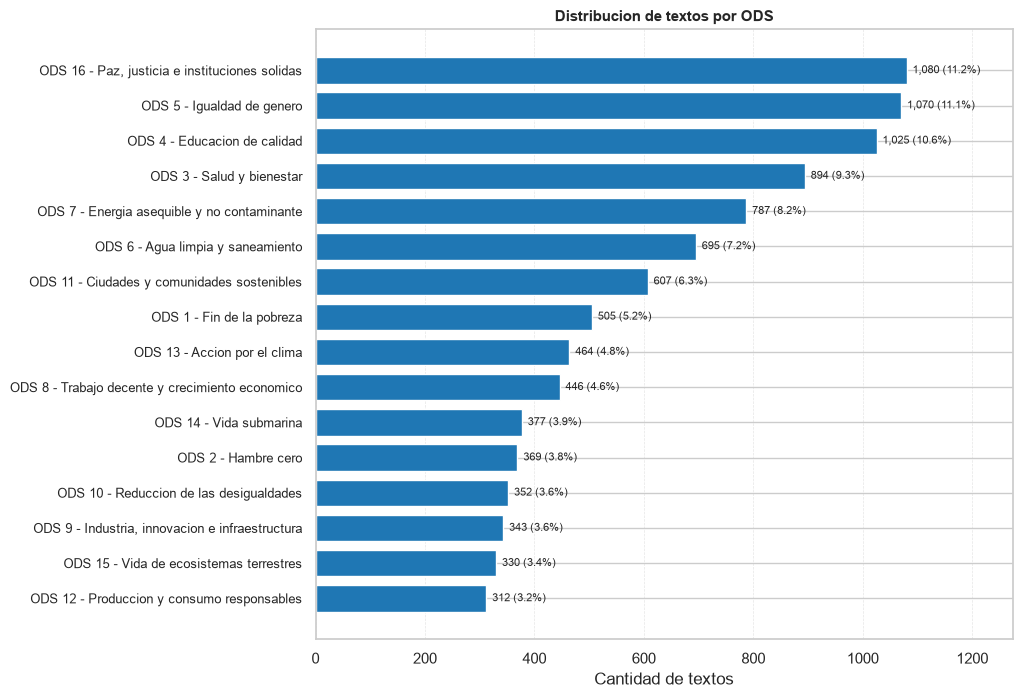

|  | ods | nombre | n_textos | porcentaje |
| --- | --- | --- | --- | --- |
| 0 | 16 | Paz, justicia e instituciones solidas | 1080 | 11.184756 |
| 1 | 5 | Igualdad de genero | 1070 | 11.081193 |
| 2 | 4 | Educacion de calidad | 1025 | 10.615162 |
| 3 | 3 | Salud y bienestar | 894 | 9.258492 |
| 4 | 7 | Energia asequible y no contaminante | 787 | 8.150373 |
| 5 | 6 | Agua limpia y saneamiento | 695 | 7.197597 |
| 6 | 11 | Ciudades y comunidades sostenibles | 607 | 6.286247 |
| 7 | 1 | Fin de la pobreza | 505 | 5.229909 |
| 8 | 13 | Accion por el clima | 464 | 4.805302 |
| 9 | 8 | Trabajo decente y crecimiento economico | 446 | 4.618890 |
| 10 | 14 | Vida submarina | 377 | 3.904308 |
| 11 | 2 | Hambre cero | 369 | 3.821458 |
| 12 | 10 | Reduccion de las desigualdades | 352 | 3.645402 |
| 13 | 9 | Industria, innovacion e infraestructura | 343 | 3.552196 |
| 14 | 15 | Vida de ecosistemas terrestres | 330 | 3.417564 |
| 15 | 12 | Produccion y consumo responsables | 312 | 3.231152 |

```
Desbalance: 1080 / 312 = 3.5x
ODS SIN representacion en el conjunto: [17]
   ODS 17: Alianzas para lograr los objetivos
```

```python
# Distribucion de textos por ODS.

def graficar_distribucion_ods(datos, ax=None):
    """Dibuja el numero de textos por ODS y devuelve la tabla de conteos.

    Retorna
    -------
    pd.DataFrame
        Columnas: ods, nombre, n_textos, porcentaje; ordenado por n_textos.
    """

    conteos = datos["ods"].value_counts().sort_values(ascending=False)

    tabla = pd.DataFrame({
        "ods": conteos.index,
        "nombre": [NOMBRES_ODS[ods] for ods in conteos.index],
        "n_textos": conteos.to_numpy(),
    })

    tabla["porcentaje"] = tabla ["n_textos"] / len(datos) * 100

    if ax is None:
        _, ax = plt.subplots(figsize=(9, 0.42 * len(tabla) + 1.2))

    etiquetas = [f"ODS {o} - {n}" for o, n in zip(tabla["ods"], tabla["nombre"])]
    y = np.arange(len(tabla))[::-1]

    ax.barh(y, tabla["n_textos"], color="tab:blue", height=0.75)

    for pos, (n, pct) in enumerate(zip(tabla["n_textos"], tabla["porcentaje"])):
        ax.text(n + max (tabla["n_textos"]) * 0.01, y[pos],
                f"{n:,} ({pct:.1f}%)",
                va="center", fontsize=8)

    ax.set_yticks(y)
    ax.set_yticklabels(etiquetas, fontsize=9)
    ax.set_xlabel("Cantidad de textos")
    ax.set_xlim(0, max(tabla["n_textos"]) * 1.18)
    ax.set_title("Distribucion de textos por ODS", fontsize=11, fontweight="bold")
    ax.grid(axis="x", alpha=0.5, linewidth=0.5, linestyle="--")

    return tabla


distribucion = graficar_distribucion_ods(datos)
plt.show()

display(distribucion)

# El desbalance condiciona la metrica de evaluacion y obliga a estratificar.
n_max, n_min = distribucion["n_textos"].max(), distribucion["n_textos"].min()
print(f"Desbalance: {n_max} / {n_min} = {n_max / n_min:.1f}x")

faltantes = sorted(set(NOMBRES_ODS) - set(datos["ods"]))
if faltantes:
    print(f"ODS SIN representacion en el conjunto: {faltantes}")
    for o in faltantes:
        print(f"   ODS {o}: {NOMBRES_ODS[o]}")
```

### Resultado: solo hay 16 de los 17 ODS

La gráfica revela dos hechos que condicionan el resto del proyecto.

**Falta un objetivo.** El conjunto contiene 16 clases, no 17: no hay ningún texto del **ODS 17, "Alianzas para lograr los objetivos"**. No es un defecto de esta descarga —el OSDG Community Dataset tampoco lo cubre— y la razón es conceptual. Mientras los ODS 1 a 16 describen ámbitos temáticos concretos, el 17 es **transversal**: trata de los medios de implementación y de la cooperación entre actores. Un texto sobre financiación internacional de proyectos de agua potable pertenece al ODS 6 por su tema y al 17 por su mecanismo, y esa ambigüedad impide que los anotadores lo asignen de forma fiable a partir del texto.

En consecuencia, **el modelo de este proyecto clasifica entre 16 clases**, y toda lectura posterior debe entenderse sobre esas 16. Un texto sobre alianzas para el desarrollo será asignado forzosamente a otro objetivo.

**Las clases están desbalanceadas, aunque de forma moderada.** En el extremo superior hay tres objetivos prácticamente empatados: ODS 16 (1.080 textos), ODS 5 (1.070) y ODS 4 (1.025), en torno al 11 % cada uno. En el inferior, un bloque de seis —ODS 14, 2, 10, 9, 15 y 12— que se mueve entre 312 y 377 textos, alrededor del 3,5 % cada uno.

La razón entre el mayor y el menor es de **3,5×**. Conviene ponerlo en perspectiva: en problemas reales de clasificación de texto son frecuentes desbalances de 50× o más. Un factor de 3,5 es lo bastante grande como para que la *exactitud* resulte engañosa —favorecería a quien acierte los objetivos grandes e ignore los pequeños— pero lo bastante contenido como para que basten dos medidas: **macro-F1** como métrica principal, que pesa igual las 16 clases, y **`class_weight="balanced"`** en los clasificadores.

**Dos preguntas quedan abiertas**

1. ¿Clasificará mejor los tres objetivos dominantes por disponer del triple de ejemplos?
2. ¿Serán los seis minoritarios los de peor rendimiento, o el problema vendrá por otro lado?

## 1.5 Longitud de los textos

La longitud determina cuánta evidencia léxica hay por documento. Textos muy cortos producen vectores TF-IDF casi vacíos y son difíciles de clasificar; textos muy largos pueden tocar varios temas y diluir la señal del objetivo principal.

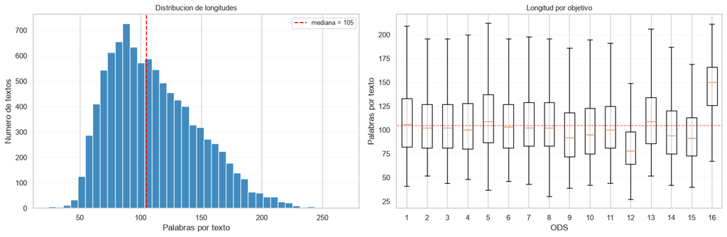

| ods | count | mean | min | 25% | 50% | 75% | max |
| --- | --- | --- | --- | --- | --- | --- | --- |
| 1 | 505.0 | 110.4 | 41.0 | 82.0 | 106.0 | 133.0 | 242.0 |
| 2 | 369.0 | 106.8 | 52.0 | 81.0 | 102.0 | 127.0 | 221.0 |
| 3 | 894.0 | 108.0 | 44.0 | 81.0 | 102.0 | 127.0 | 238.0 |
| 4 | 1025.0 | 106.6 | 48.0 | 80.0 | 100.0 | 128.0 | 260.0 |
| 5 | 1070.0 | 114.7 | 37.0 | 87.0 | 109.0 | 137.0 | 245.0 |
| 6 | 695.0 | 108.3 | 46.0 | 81.0 | 103.0 | 127.0 | 239.0 |
| 7 | 787.0 | 108.4 | 43.0 | 83.0 | 102.0 | 129.0 | 234.0 |
| 8 | 446.0 | 108.7 | 30.0 | 83.0 | 102.0 | 128.8 | 255.0 |
| 9 | 343.0 | 98.8 | 39.0 | 72.0 | 92.0 | 118.0 | 238.0 |
| 10 | 352.0 | 102.0 | 42.0 | 75.0 | 95.0 | 123.0 | 224.0 |
| 11 | 607.0 | 106.5 | 44.0 | 81.0 | 100.0 | 125.0 | 222.0 |
| 12 | 312.0 | 84.9 | 27.0 | 64.0 | 78.0 | 98.0 | 210.0 |
| 13 | 464.0 | 113.9 | 52.0 | 86.0 | 109.0 | 134.0 | 253.0 |
| 14 | 377.0 | 102.1 | 42.0 | 75.0 | 94.0 | 120.0 | 248.0 |
| 15 | 330.0 | 96.0 | 40.0 | 73.0 | 91.5 | 113.0 | 209.0 |
| 16 | 1080.0 | 143.8 | 24.0 | 125.8 | 150.0 | 166.0 | 268.0 |

```python
# Distribucion de la longitud de los textos, global y por ODS.

def analizar_longitud(datos):
    """Resume la longitud de los textos y la compara entre objetivos.

    Retorna
    -------
    pd.DataFrame
        Percentiles de n_palabras por ODS.
    """

    fig, axes = plt.subplots(1, 2, figsize=(15, 5))

    # Panel izquierdo: distribucion global
    mediana = datos["n_palabras"].median()

    axes[0].hist(datos["n_palabras"], bins=40, color="tab:blue", alpha=0.85)
    axes[0].axvline(mediana, color="red", linestyle="--", linewidth=1.5,
                    label=f"mediana = {mediana:.0f}")
    axes[0].set_xlabel("Palabras por texto")
    axes[0].set_ylabel("Numero de textos")
    axes[0].set_title("Distribucion de longitudes", fontsize=11)
    axes[0].legend(fontsize=9)

    # Panel derecho: comparacion entre objetivos
    ods_ordenadas = sorted(datos["ods"].unique())
    grupos = [datos.loc[datos["ods"] == o, "n_palabras"].to_numpy()
              for o in ods_ordenadas]

    axes[1].boxplot(grupos, tick_labels=ods_ordenadas, showfliers=False)
    axes[1].axhline(mediana, color="red", linestyle="--", linewidth=1,
                    alpha=0.6)
    axes[1].set_xlabel("ODS")
    axes[1].set_ylabel("Palabras por texto")
    axes[1].set_title("Longitud por objetivo", fontsize=11)

    for ax in axes:
        ax.grid(axis="y", alpha=0.3, linewidth=0.5)

    plt.tight_layout()

    return datos.groupby("ods")["n_palabras"].describe()


longitudes = analizar_longitud(datos)
plt.show()

display(longitudes[["count", "mean", "min", "25%", "50%", "75%", "max"]].round(1))
```

## 1.6 Partición estratificada

La partición se hace **ahora, antes de cualquier transformación**. El motivo es evitar la **fuga de información**: si el vocabulario TF-IDF o la descomposición SVD se aprendieran sobre el conjunto completo, el modelo habría visto indirectamente los textos de test durante su construcción, y la evaluación final dejaría de medir capacidad de generalización para medir memoria.

Por eso todas las transformaciones de las secciones siguientes se encapsulan en un `Pipeline` de scikit-learn, que garantiza que el ajuste ocurre solo con los datos de entrenamiento de cada pliegue.

Decision:

- **Estratificar por ODS.** Con un desbalance de 3,5×, una partición aleatoria simple podría dejar muy pocos textos del ODS 12 en test y hacer su métrica inestable.

```python
# Particion estratificada.

def particionar(datos, proporcion_test=PROPORCION_TEST, semilla=SEMILLA):
    """Divide en entrenamiento y test conservando la proporcion de cada ODS.

    Retorna
    -------
    X_train, X_test : pd.Series de textos
    y_train, y_test : pd.Series de etiquetas
    """

    minimo = datos["ods"].value_counts().min()
    if minimo < 2:
        raise ValueError(
            f"Hay un ODS con solo {minimo} texto(s): no se puede estratificar, "
            f"se necesitan al menos 2 por clase."
        )

    X_train, X_test, y_train, y_test = train_test_split(
        datos["texto"],
        datos["ods"],
        test_size= proporcion_test,
        stratify= datos["ods"],
        random_state= semilla
        )

    return X_train, X_test, y_train, y_test


X_train, X_test, y_train, y_test = particionar(datos)

print(f"Entrenamiento: {len(X_train):,} textos")
print(f"Test         : {len(X_test):,} textos")

# Comprobacion de que la estratificacion funciono: las proporciones de cada
# clase deben coincidir entre ambos conjuntos.
comparacion_particion = pd.DataFrame({
    "train_%": y_train.value_counts(normalize=True).sort_index() * 100,
    "test_%": y_test.value_counts(normalize=True).sort_index() * 100,
})
comparacion_particion["diferencia"] = (
    comparacion_particion["train_%"] - comparacion_particion["test_%"]
).abs()

display(comparacion_particion.round(2))

assert comparacion_particion["diferencia"].max() < 1.0, \
    "La estratificacion no conservo las proporciones"
print("\nEstratificacion correcta: ninguna clase difiere mas de 1 punto porcentual.")
```

```
Entrenamiento: 7,724 textos
Test         : 1,932 textos
```

| ods | train_% | test_% | diferencia |
| --- | --- | --- | --- |
| 1 | 5.23 | 5.23 | 0.00 |
| 2 | 3.82 | 3.83 | 0.01 |
| 3 | 9.26 | 9.27 | 0.01 |
| 4 | 10.62 | 10.61 | 0.01 |
| 5 | 11.08 | 11.08 | 0.01 |
| 6 | 7.20 | 7.19 | 0.00 |
| 7 | 8.14 | 8.18 | 0.03 |
| 8 | 4.62 | 4.61 | 0.02 |
| 9 | 3.55 | 3.57 | 0.02 |
| 10 | 3.65 | 3.62 | 0.03 |
| 11 | 6.28 | 6.31 | 0.04 |
| 12 | 3.24 | 3.21 | 0.03 |
| 13 | 4.80 | 4.81 | 0.01 |
| 14 | 3.91 | 3.88 | 0.03 |
| 15 | 3.42 | 3.42 | 0.00 |
| 16 | 11.19 | 11.18 | 0.01 |

```
Estratificacion correcta: ninguna clase difiere mas de 1 punto porcentual.
```

# 2. Preparación del texto y pipeline

## 2.1 Decisiones de preparación y su justificación

Un texto en bruto no es una entrada válida para un algoritmo. Convertirlo en números exige una cadena de decisiones, y cada una descarta información a cambio de generalización.

| # | Decisión | Justificación |
| --- | --- | --- |
| 1 | **Pasar a minúsculas** | "Pobreza" al principio de una frase y "pobreza" en medio son el mismo término. Mantener la distinción fragmentaría el conteo entre dos entradas del vocabulario que significan lo mismo. |
| 2 | **Eliminar acentos** | La traducción automática y la aumentación producen inconsistencias de tildes dentro del mismo corpus. Sin normalizar, "educación" y "educacion" serían términos distintos y su evidencia quedaría partid… |
| 3 | **Eliminar dígitos y puntuación** | Las cifras concretas —años, porcentajes, códigos de informe— son específicas de cada documento y no generalizan a textos nuevos. Solo inflan el vocabulario con términos que aparecen una vez. |
| 4 | **Eliminar *stopwords* en español** | Artículos, preposiciones y conjunciones aparecen con frecuencia parecida en los 16 objetivos: no discriminan entre clases y, al ser los términos más frecuentes, dominarían la matriz. NLTK aporta 313 p… |
| 5 | **Aplicar *stemming*** (`SnowballStemmer`) | Reduce "sostenible", "sostenibles" y "sostenibilidad" a una raíz común. Sin él, la evidencia de un mismo concepto queda repartida entre varias columnas. |
| 6 | **Descartar tokens de menos de 3 caracteres** | Tras el *stemming* quedan fragmentos sin valor semántico. |

### Por qué *stemming* y no lematización

La alternativa habría sido lematizar con spaCy, que devuelve la forma de diccionario real ("corriendo" → "correr") en lugar del truncamiento que produce el *stemmer* ("corr"). La lematización da tópicos más legibles, pero exige descargar un modelo de lengua y es considerablemente más lenta sobre casi diez mil textos.

Se optó por el *stemming* porque el objetivo aquí es **agrupar variantes de un mismo concepto**, y para eso basta con que todas caigan en la misma raíz aunque esa raíz no sea una palabra.

## 2.2 Por qué bolsa de palabras con pesado TF-IDF

La **bolsa de palabras (BOW)** representa cada documento por las palabras que contiene y cuántas veces, descartando el orden. Es una simplificación fuerte —"la pobreza causa hambre" y "el hambre causa pobreza" resultan idénticos— pero conserva justo lo que distingue un ODS de otro: **la evidencia léxica**. Un texto sobre el ODS 6 hablará de agua, saneamiento y potabilidad independientemente de cómo ordene esas palabras.

El problema del conteo puro es que los términos más frecuentes no son los más informativos. **TF-IDF** corrige esto combinando dos factores:

$$\text{tf-idf}(t, d) = \text{tf}(t,d) \times \log\frac{N}{\text{df}(t)}$$

- **TF** (*term frequency*) premia lo que se repite dentro del documento.
- **IDF** (*inverse document frequency*) penaliza lo que aparece en toda la colección.

El efecto combinado es el deseado: "agua" pesa mucho en un texto del ODS 6 que la menciona repetidamente, y poco en uno que la cita de pasada; y un término como "desarrollo", presente en casi todos los textos del corpus, queda con peso bajo pese a su frecuencia.

### Los dos logaritmos: por qué la importancia no crece con la frecuencia

En la fórmula anterior hay **dos logaritmos con propósitos distintos**, y ambos existen para lo mismo: **la importancia de un término no crece de forma proporcional a su frecuencia**. Ninguno es un detalle de implementación; sin ellos TF-IDF no funcionaría.

#### El logaritmo del TF: amortigua la repetición dentro del documento

Que "agua" aparezca diez veces en un texto no lo hace diez veces más sobre el agua que otro donde aparece una vez. La primera aparición es la que aporta casi toda la información —revela el tema—; la décima apenas añade nada. Es una relación **sublineal**, y por eso `sublinear_tf=True` sustituye la frecuencia bruta por $1 + \ln(\text{tf})$:

| Veces que aparece | % de casos en este corpus | Peso lineal | Peso $1+\ln(\text{tf})$ |
| --- | --- | --- | --- |
| 1 | 84,5 % | 1 | 1,00 |
| 2 | 11,1 % | 2 | 1,69 |
| 3 | 2,7 % | 3 | 2,10 |
| 5 | 0,5 % | 5 | 2,61 |
| 10 | ~0 % | 10 | 3,30 |

Pasar de una aparición a diez multiplica el peso **por 3,3 en lugar de por 10**. Sin esa amortiguación, un texto que repita insistentemente un término dominaría sobre otro que lo trate con la misma profundidad pero sin repetirse, y el modelo confundiría *insistencia* con *relevancia*.

#### El logaritmo del IDF: amortigua la rareza en la colección

El IDF hace lo simétrico, pero entre documentos. Si se usara la razón cruda $N/\text{df}$, un término presente en un solo documento pesaría **7.724**, y uno presente en cincuenta pesaría 154: cincuenta veces más por ser cincuenta veces más raro.

| Aparece en | $N/\text{df}$ (sin logaritmo) | IDF real (con logaritmo) |
| --- | --- | --- |
| 1 documento | 7.724 | 9,26 |
| 5 documentos | 1.545 | 8,16 |
| 50 documentos | 154 | 6,02 |
| 500 documentos | 15 | 3,74 |
| 3.000 documentos | 3 | 1,95 |

Sin amortiguar, los términos que aparecen una sola vez —erratas de la traducción automática, nombres propios, cifras sueltas— tendrían pesos abrumadores y **secuestrarían la matriz entera**. Serían los términos más "informativos" según la fórmula, precisamente por ser los que menos permiten generalizar a textos nuevos.

En resumen: **el TF logarítmico impide que un documento verboso domine; el IDF logarítmico impide que un término anecdótico domine.** Los dos convierten una relación explosiva en una escala comparable, que es lo que permite sumar y comparar vectores de documentos distintos.

### Parámetros del vectorizador

| Parámetro | Valor | Por qué |
| --- | --- | --- |
| `min_df` | 5 | Un término que aparece en menos de 5 documentos no permite generalizar: es una errata, un nombre propio o un tecnicismo aislado. |
| `max_df` | 0.8 | Un término presente en más del 80 % de los documentos no discrimina entre objetivos. |
| `ngram_range` | (1, 2) | Los bigramas capturan conceptos que las palabras sueltas pierden: "cambio climático", "igualdad género", "energía renovable". Es donde BOW recupera parte de lo que descarta al ignorar el orden. |
| `sublinear_tf` | `True` | Sustituye la frecuencia por $1 + \log(\text{tf})$. Que un término aparezca diez veces no lo hace diez veces más relevante que si apareciera una; el logaritmo amortigua ese efecto. |

## 2.3 Transformador de normalización

La normalización se implementa como una clase que sigue la API de scikit-learn. Esto permite encadenarla en un `Pipeline` y, sobre todo, que su comportamiento quede bajo el control de la validación cruzada.

```python
# Transformador de normalizacion del texto, siguiendo la API de scikit-learn.

def normalizar_token(texto):
    """Pasa un texto a minusculas y le quita los acentos, conservando la ene.

    NFKD descompone 'n' en 'n' mas una tilde combinante, asi que filtrar las
    combinantes la convertiria en una 'n' normal. Se sustituye por un caracter
    de control antes de descomponer y se restaura despues.

    Esta funcion se aplica TANTO al texto COMO a la lista de stopwords: si solo
    se normalizara uno de los dos lados, "mas" del texto nunca coincidiria con
    "mas" de la lista y esa stopword no llegaria a filtrarse.
    """
    texto = str(texto).lower().replace("\u00f1", "\x01")
    texto = "".join(
        c for c in unicodedata.normalize("NFKD", texto)
        if not unicodedata.combining(c)
    )
    return texto.replace("\x01", "\u00f1")


# Las stopwords se materializan AQUI, una sola vez, como cadenas planas.
STOPWORDS_POR_IDIOMA = {
    idioma: frozenset(normalizar_token(p) for p in stopwords.words(idioma))
    for idioma in ("spanish",)
}


class NormalizadorTexto(BaseEstimator, TransformerMixin):
    """Normaliza textos en espanol antes de la vectorizacion.

    Aplica, en orden: minusculas, eliminacion de acentos, eliminacion de
    digitos y puntuacion, filtrado de stopwords, stemming y descarte de
    tokens demasiado cortos.

    Parametros
    ----------
    aplicar_stemming : bool
        Si False, omite el paso de stemming. Permite medir su efecto sobre
        el tamano del vocabulario.
    longitud_minima : int
        Longitud minima de un token para conservarlo.
    idioma : str
        Idioma de las stopwords y del stemmer.
    """

    def __init__(self, aplicar_stemming=True, longitud_minima=3, idioma="spanish"):
        self.aplicar_stemming = aplicar_stemming
        self.longitud_minima = longitud_minima
        self.idioma = idioma

    def fit(self, X, y=None):
        # No aprende nada de los datos, pero prepara los recursos una sola vez

        if self.idioma not in STOPWORDS_POR_IDIOMA:
            raise ValueError(
                f"Idioma sin stopwords precargadas: {self.idioma!r}. "
                f"Anadelo a STOPWORDS_POR_IDIOMA."
            )

        self.stopwords_ = STOPWORDS_POR_IDIOMA[self.idioma]
        self.stemmer_ = SnowballStemmer(self.idioma)
        self.ajustado_ = True

        return self

    def _normalizar(self, texto):
        """Normaliza un unico texto y devuelve la cadena de tokens resultante."""

        texto = normalizar_token(texto)
        texto = re.sub(r"[^a-zñ\s]", " ", texto)

        tokens = [
            t for t in texto.split()
            if t not in self.stopwords_ and len(t) >= self.longitud_minima
        ]

        if self.aplicar_stemming:
            tokens = [self.stemmer_.stem(t) for t in tokens]

        return " ".join(tokens)

    def transform(self, X):
        """Aplica la normalizacion a una serie o lista de textos."""
        check_is_fitted(self)
        return [self._normalizar(t) for t in X]
```

## 2.4 Construcción del pipeline de preparación

Los dos pasos —normalización y vectorización TF-IDF— se encadenan en un `Pipeline`. Frente a llamarlos por separado, esto aporta algo que aquí es decisivo:

**Cuando el `Pipeline` entra en `GridSearchCV`, el vocabulario se reaprende en cada pliegue de la validación cruzada, usando solo los datos de entrenamiento de ese pliegue.** Hacerlo a mano exigiría reajustar el vectorizador dentro del bucle de validación, y olvidarlo. El `Pipeline` lo vuelve imposible por construcción.

Como beneficio adicional, los hiperparámetros de cualquier etapa quedan accesibles desde fuera con la sintaxis `etapa__parametro`, lo que permite incluir en la búsqueda decisiones como el rango de n-gramas o el número de componentes del LSA.

```python
# Pipeline de preparacion: texto crudo -> matriz TF-IDF.

def construir_pipeline_texto(aplicar_stemming=True, min_df=5, max_df=0.8,
                             ngram_range=(1, 2), sublinear_tf=True):
    """Arma el pipeline que va de textos crudos a una matriz TF-IDF dispersa.

    Etapas: normalizar -> vectorizar.

    Retorna
    -------
    sklearn.pipeline.Pipeline
        Sin ajustar. Usar .fit_transform(X_train) la primera vez.
    """

    return Pipeline([
        ("normalizar", NormalizadorTexto(aplicar_stemming=aplicar_stemming)),
        ("vectorizar", TfidfVectorizer(
            min_df=min_df,
            max_df=max_df,
            ngram_range=ngram_range,
            sublinear_tf=sublinear_tf
        )),
    ])


pipeline_texto = construir_pipeline_texto()
pipeline_texto
```

```
Pipeline(steps=[('normalizar', NormalizadorTexto()),
                ('vectorizar',
                 TfidfVectorizer(max_df=0.8, min_df=5, ngram_range=(1, 2),
                                 sublinear_tf=True))])
```

## 2.5 Verificación del pipeline

Antes de seguir conviene comprobar tres cosas: que la matriz tiene las dimensiones esperadas, que su densidad es la típica de un problema de texto, y que el vocabulario resultante tiene sentido.

La comprobación más informativa son los **términos de IDF extremo**. Los de IDF más bajo son los que aparecen en casi todos los documentos —deberían ser genéricos del dominio, como "desarroll" o "pais"— y los de IDF más alto, los más específicos. Si entre los primeros aparecieran *stopwords*, el filtrado habría fallado.

Se mide además el efecto del *stemming* sobre el tamaño del vocabulario, que es la forma de cuantificar lo que aporta esa decisión de §2.1.

```python
# Comprobacion del pipeline sobre el conjunto de entrenamiento.

def verificar_pipeline(X_train, pipeline):
    """Ajusta el pipeline y resume la matriz TF-IDF resultante.

    Retorna
    -------
    dict con la matriz, el vocabulario y las estadisticas basicas.
    """

    inicio = time.perf_counter()
    X = pipeline.fit_transform(X_train)
    segundos = time.perf_counter() - inicio

    vectorizador = pipeline.named_steps["vectorizar"]
    vocabulario = vectorizador.get_feature_names_out()

    n_bigramas = sum(" " in t for t in vocabulario)
    densidad = X.nnz / (X.shape[0] * X.shape[1])

    # Cuantos terminos descartaron min_df y max_df.
    sin_filtros = TfidfVectorizer(
        ngram_range=vectorizador.ngram_range, min_df=1, max_df=1.0
    ).fit(pipeline.named_steps["normalizar"].transform(X_train))
    n_descartados = len(sin_filtros.get_feature_names_out()) - len(vocabulario)

    resumen = {
        "matriz": X,
        "vocabulario": vocabulario,
        "forma": X.shape,
        "densidad": densidad,
        "n_unigramas": len(vocabulario) - n_bigramas,
        "n_bigramas": n_bigramas,
        "descartados_frecuencia": n_descartados,
        "docs_vacios": int((X.getnnz(axis=1) == 0).sum()),
        "segundos": segundos,
    }

    return resumen


resultado_tfidf = verificar_pipeline(X_train, pipeline_texto)

print(f"Matriz TF-IDF   : {resultado_tfidf['forma'][0]:,} documentos x " f"{resultado_tfidf['forma'][1]:,} terminos")
print(f"Densidad        : {resultado_tfidf['densidad']:.4%}")
print(f"Unigramas       : {resultado_tfidf['n_unigramas']:,}")
print(f"Bigramas        : {resultado_tfidf['n_bigramas']:,}")
print(f"Descartados por min_df/max_df: {resultado_tfidf['descartados_frecuencia']:,}")
print(f"Documentos sin ningun termino : {resultado_tfidf['docs_vacios']}")
print(f"Tiempo de ajuste: {resultado_tfidf['segundos']:.1f} s")
```

```
Matriz TF-IDF   : 7,724 documentos x 13,592 terminos
Densidad        : 0.4131%
Unigramas       : 4,532
Bigramas        : 9,060
Descartados por min_df/max_df: 266,396
Documentos sin ningun termino : 0
Tiempo de ajuste: 2.0 s
```

```python
# Terminos de IDF extremo y efecto del stemming sobre el vocabulario.

def inspeccionar_vocabulario(pipeline, n=20):
    """Muestra los terminos de IDF mas bajo y mas alto.

    Los de IDF bajo aparecen en casi todos los documentos y deberian ser
    genericos del dominio; los de IDF alto son los mas especificos.
    """

    vectorizador = pipeline.named_steps["vectorizar"]
    terminos = vectorizador.get_feature_names_out()
    idf = vectorizador.idf_

    orden = np.argsort(idf)

    genericos = orden[:n]
    especificos = orden[-n:]

    return pd.DataFrame({
        "genericos": terminos[genericos],
        "idf_genericos": np.round(idf[genericos], 2),
        "especificos": terminos[especificos],
        "idf_especificos": np.round(idf[especificos], 2),
    })

display(inspeccionar_vocabulario(pipeline_texto))

# Cuanto reduce el stemming el tamano del vocabulario.

pipeline_sin_stem = construir_pipeline_texto(aplicar_stemming=False)
X_sin_stem = pipeline_sin_stem.fit_transform(X_train)

vocab_con = len(resultado_tfidf["vocabulario"])
vocab_sin = len(pipeline_sin_stem.named_steps["vectorizar"].get_feature_names_out())

reduccion = (vocab_sin - vocab_con) / vocab_sin * 100

print(f"Sin stemming: {vocab_sin:,} terminos")
print(f"Con stemming: {vocab_con:,} terminos")
print(f"Reduccion:    {reduccion:.1f}% ")

densidad_con = resultado_tfidf["matriz"].nnz / np.prod(resultado_tfidf["forma"])
densidad_sin = X_sin_stem.nnz / np.prod(X_sin_stem.shape)
print(f"Densidad con stemming: {densidad_con:.4%}")
print(f"Densidad sin stemming: {densidad_sin:.4%}")
```

|  | genericos | idf_genericos | especificos | idf_especificos |
| --- | --- | --- | --- | --- |
| 0 | pued | 2.23 | examin divers | 8.16 |
| 1 | pais | 2.32 | rent person | 8.16 |
| 2 | desarroll | 2.40 | examin critic | 8.16 |
| 3 | polit | 2.54 | investig sugier | 8.16 |
| 4 | part | 2.69 | investig univers | 8.16 |
| 5 | mejor | 2.69 | exager | 8.16 |
| 6 | aument | 2.72 | climat mitig | 8.16 |
| 7 | deb | 2.74 | evolu polit | 8.16 |
| 8 | nivel | 2.76 | climat nacional | 8.16 |
| 9 | sistem | 2.84 | evitari | 8.16 |
| 10 | mayor | 2.84 | repas | 8.16 |
| 11 | inclu | 2.85 | evident pais | 8.16 |
| 12 | import | 2.88 | evident internacional | 8.16 |
| 13 | embarg | 2.89 | cad sex | 8.16 |
| 14 | trabaj | 2.89 | evident indic | 8.16 |
| 15 | public | 2.89 | climat podri | 8.16 |
| 16 | ejempl | 2.92 | evapotranspir | 8.16 |
| 17 | nacional | 2.97 | evapor | 8.16 |
| 18 | cambi | 2.99 | pecuniari | 8.16 |
| 19 | baj | 3.01 | insum agricol | 8.16 |

```
Sin stemming: 14,357 terminos
Con stemming: 13,592 terminos
Reduccion:    5.3%
Densidad con stemming: 0.4131%
Densidad sin stemming: 0.3647%
```

### Resultado de la preparación

El pipeline produce una matriz de **7.724 documentos × 13.592 términos** con una densidad del **0,41 %**: de los casi 105 millones de celdas, apenas 430.000 tienen un valor distinto de cero.

**El filtrado por frecuencia descartó 266.396 términos.** Sumados a los 13.592 conservados, el vectorizador llegó a ver casi 280.000 términos distintos, de modo que `min_df` y `max_df` se quedaron con **menos del 5 %**. La mayor parte de lo descartado son bigramas que aparecen una sola vez en todo el corpus y que no permitirían generalizar a ningún texto nuevo.

**Los términos de IDF bajo confirman que el ponderado funciona.** Los veinte más genéricos son de dos tipos: vocabulario del dominio (`pais`, `desarroll`, `polit`, `nacional`), presente en el 21-29 % de los documentos, y conectores del registro académico (`pued`, `deb`, `embarg`, `ejempl`) que la lista de *stopwords* de NLTK no cubre por no ser artículos ni preposiciones. **No hizo falta filtrarlos a mano**: al aparecer en una cuarta parte del corpus, el IDF ya les asigna el peso mínimo y los neutraliza solo.

**Dos tercios del vocabulario son bigramas**: 9.060 frente a 4.532 unigramas, exactamente el doble. La asimetría se aprecia también en los extremos del IDF —los veinte términos más genéricos son todos unigramas, mientras que catorce de los veinte más raros son bigramas—. Es coherente: un par concreto de palabras es mucho menos frecuente que una palabra suelta.

# 3. Modelo LSA y tópicos latentes

## 3.1 Qué es LSA y por qué SVD truncado

Matemáticamente es una descomposición en valores singulares truncada:

$$X \approx U_k \Sigma_k V_k^\top$$

donde $k$ es el número de conceptos que se conservan. Las filas de $U_k \Sigma_k$ son los documentos en el espacio latente; las de $V_k$ dicen cuánto pesa cada término en cada concepto, y son las que se leen como "tópicos".

### Por qué `TruncatedSVD` y no PCA

`TruncatedSVD` opera directamente sobre la representación dispersa sin centrar, y por eso es la implementación estándar de LSA en scikit-learn.

### El `Normalizer` posterior

La salida de la SVD no tiene norma constante: documentos largos producen vectores de mayor magnitud. Como los clasificadores que se usarán después dependen de distancias y productos escalares, se añade un `Normalizer` que lleva cada vector a norma unitaria. Es la convención habitual en LSA y hace que la comparación entre documentos dependa de su **dirección** en el espacio de conceptos, no de su longitud.

## 3.2 Elección del número de componentes

El mismo modelo LSA sirve a dos propósitos distintos en este notebook:

- **Para interpretar tópicos** interesan **pocas** componentes. Con 15 conceptos cada uno agrupa un tema amplio y reconocible; con 300, cada componente captura un matiz demasiado fino para ponerle nombre.
- **Para clasificar** suelen hacer falta **muchas más**. Cada componente adicional aporta capacidad discriminativa, y el óptimo está típicamente en el orden de los cientos.

Se resuelve usando el LSA dos veces con propósitos separados: **15 componentes** para el modelo de tópicos interpretable de esta sección, y el número como **hiperparámetro** de la búsqueda de §5.4. No es una inconsistencia sino dos usos legítimos de la misma técnica.

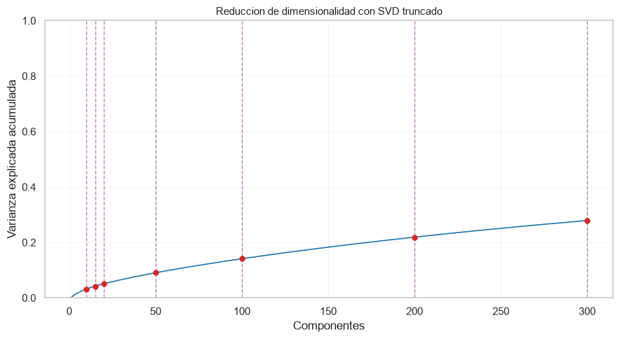

|  | componentes | varianza_acumulada | reduccion_dim |
| --- | --- | --- | --- |
| 0 | 10 | 0.031990 | 0.999264 |
| 1 | 15 | 0.042254 | 0.998896 |
| 2 | 20 | 0.050720 | 0.998529 |
| 3 | 50 | 0.090626 | 0.996321 |
| 4 | 100 | 0.141143 | 0.992643 |
| 5 | 200 | 0.219027 | 0.985285 |
| 6 | 300 | 0.278813 | 0.977928 |

```python
# Curva de varianza explicada para elegir el numero de componentes.

def analizar_componentes(X_tfidf, maximos=(10, 15, 20, 50, 100, 200, 300), semilla=SEMILLA):
    """Ajusta un SVD con el maximo de componentes y traza la varianza acumulada.

    Retorna
    -------
    pd.DataFrame
        Varianza explicada acumulada en cada numero de componentes de interes.
    """

    tope = min(max(maximos), X_tfidf.shape[1] - 1, X_tfidf.shape[0] - 1)
    maximos = [m for m in maximos if m <= tope]

    svd = TruncatedSVD(n_components=tope, random_state=semilla)
    svd.fit(X_tfidf)

    acumulada = np.cumsum(svd.explained_variance_ratio_)

    fig, ax = plt.subplots(figsize=(9, 5))
    ax.plot(np.arange(1, tope + 1), acumulada, color="tab:blue", linewidth=1.2)

    for m in maximos:
        ax.axvline(m, color="purple", linestyle="--", linewidth=1, alpha=0.5)
        ax.plot(m, acumulada[m - 1], "o", color="tab:red", markersize=5)

    ax.set_xlabel("Componentes")
    ax.set_ylabel("Varianza explicada acumulada")
    ax.set_title("Reduccion de dimensionalidad con SVD truncado", fontsize=11)
    ax.set_ylim(0, 1)
    ax.grid(alpha=0.3, linewidth=0.5)
    plt.tight_layout()

    return pd.DataFrame({
        "componentes": maximos,
        "varianza_acumulada": [acumulada[m - 1] for m in maximos],
        "reduccion_dim": [1 - m / X_tfidf.shape[1] for m in maximos],
    })


varianza = analizar_componentes(resultado_tfidf["matriz"])
plt.show()

display(varianza)
```

### Resultado

La curva confirma lo que anticipaba esta sección: **en texto la varianza está muy repartida**. Con 15 componentes se conserva apenas el **4,2 %** de la varianza original, y ni siquiera con 300 se llega al 28 %.

En un problema tabular ese número sería alarmante. Aquí es lo esperable, y la razón es de fondo: el corpus trata dieciséis temas distintos con miles de palabras distintas, de modo que no existen unos pocos ejes dominantes que resuman la variabilidad. Cada componente captura un matiz temático y ninguna domina.

**Cómo leer los saltos.** Los valores de la primera columna no están igualmente espaciados —10, 15, 20, 50, 100, 200, 300—, así que comparar los incrementos entre filas induce a error: el salto de 100 a 200 parece el mayor de todos (+7,8 puntos) simplemente porque añade cien componentes. Lo informativo es el aporte **por componente**:

| Tramo | Componentes añadidas | Varianza ganada | Ganancia por componente |
| --- | --- | --- | --- |
| 10 → 15 | 5 | +1,03 pp | **0,205 pp** |
| 15 → 20 | 5 | +0,85 pp | 0,169 pp |
| 20 → 50 | 30 | +3,99 pp | 0,133 pp |
| 50 → 100 | 50 | +5,05 pp | 0,101 pp |
| 100 → 200 | 100 | +7,79 pp | 0,078 pp |
| 200 → 300 | 100 | +5,98 pp | **0,060 pp** |

Visto así aparece el comportamiento real: **cada componente adicional aporta menos que la anterior**, de forma sostenida y sin saltos bruscos. De las primeras a las últimas, el rendimiento por componente se divide por tres y medio.

**No hay codo.** El descenso es tan suave que la curva nunca se dobla lo suficiente como para señalar un número óptimo. Esa ausencia es informativa en sí misma y justifica la decisión de usar el LSA **dos veces con criterios distintos**: 15 componentes para tópicos interpretables y el número como hiperparámetro de la clasificación. Si existiera un codo claro, ese valor serviría para ambos usos; como no lo hay, cada uno elige según su propio objetivo —legibilidad en un caso, macro-F1 en el otro.

**La compresión sigue siendo enorme en todo el rango.** Incluso con 300 componentes se conserva solo el 2,2 % de las 13.592 columnas originales: una reducción del **97,8 %**. Aunque la varianza retenida parezca baja, el espacio se comprime drásticamente en cualquiera de las opciones consideradas.

## 3.3 Extracción de los tópicos

Cada componente latente es una combinación lineal de todos los términos del vocabulario. Los términos con mayor peso en valor absoluto son los que definen el concepto, y leerlos juntos permite ponerle nombre.

Para interpretarlos correctamente:

- **El signo de una componente es arbitrario.** La SVD podría devolver la componente multiplicada por $-1$ y seria igual de válida. Lo que importa es que unos términos tengan peso alto y otros bajo, no si el número es positivo o negativo. Por eso se ordena por **valor absoluto**.
- **La componente 1 suele ser degenerada.** Al no centrar los datos, la primera dimensión captura la dirección media del corpus y sus términos de mayor peso tienden a ser los genéricos del dominio ("desarroll", "pais", "polit"). No corresponde a ningún ODS: representa "el tema común de todos los textos". Hay una forma de confirmarlo con un número: **su varianza explicada será de las más bajas de todas**, pese a ser la primera. Es contraintuitivo en un SVD, y justamente esa es la señal — todos los documentos se proyectan de forma parecida sobre ella, así que aporta magnitud pero casi ninguna varianza.

```python
# Ajuste del LSA interpretable y extraccion de sus topicos.

def ajustar_lsa(X_tfidf, n_componentes=N_COMPONENTES_TOPICOS, semilla=SEMILLA):
    """Ajusta el SVD truncado que se usara para interpretar topicos.

    Retorna
    -------
    svd : TruncatedSVD ajustado
    X_lsa : ndarray (n_documentos, n_componentes) ya normalizado
    """

    svd = TruncatedSVD(n_components=n_componentes, random_state=semilla)
    X_lsa = svd.fit_transform(X_tfidf)
    X_lsa = Normalizer(copy=False).fit_transform(X_lsa)

    return svd, X_lsa


def extraer_topicos(svd, vocabulario, n_palabras=12):
    """Palabras de mayor peso en cada componente latente.

    Parametros
    ----------
    svd : TruncatedSVD ajustado
    vocabulario : array de str
        Salida de get_feature_names_out() del vectorizador.
    n_palabras : int
        Terminos a mostrar por componente.

    Retorna
    -------
    pd.DataFrame
        Una fila por componente: numero, varianza explicada y las palabras
        dominantes separadas por comas.
    """

    vocabulario = np.array(vocabulario)
    filas = []

    for i, componente in enumerate(svd.components_, start=1):
        orden = np.argsort(np.abs(componente))[::-1][:n_palabras]
        orden = orden[np.argsort(componente[orden])[::-1]]  # Ordenar por valor real

        palabras = [
            f"{vocabulario[j]}{'' if componente[j] >= 0 else ' (-)'}"
            for j in orden
        ]

        filas.append({
            "componente": i,
            "varianza": svd.explained_variance_ratio_[i - 1],
            "palabras": ", ".join(palabras)
        })

    return pd.DataFrame(filas)



svd_topicos, X_lsa_topicos = ajustar_lsa(resultado_tfidf["matriz"])
topicos = extraer_topicos(svd_topicos, resultado_tfidf["vocabulario"])

print(f"Varianza explicada por {N_COMPONENTES_TOPICOS} componentes: "
      f"{svd_topicos.explained_variance_ratio_.sum():.1%}")
display(topicos)
```

```
Varianza explicada por 15 componentes: 4.2%
```

|  | componente | varianza | palabras |
| --- | --- | --- | --- |
| 0 | 1 | 0.000915 | pued, pais, desarroll, polit, mejor, trabaj, m... |
| 1 | 2 | 0.005135 | derech, derech human, human, internacional, ar... |
| 2 | 3 | 0.004788 | mujer, trabaj, educ, hombr, niñ, laboral, ingr... |
| 3 | 4 | 0.003918 | educ, escuel, estudi, docent, aprendizaj, prog... |
| 4 | 5 | 0.003349 | salud, agu, atencion, medic, mental, servici, ... |
| 5 | 6 | 0.003129 | mujer, salud, atencion, servici, gener, hombr,... |
| 6 | 7 | 0.003056 | agu, mujer, gestion, hombr, medic (-), energi ... |
| 7 | 8 | 0.002940 | climat, cambi climat, desarroll, cambi, pobrez... |
| 8 | 9 | 0.002435 | pais, climat, ocde, mujer, energi, gener, info... |
| 9 | 10 | 0.002312 | pued, cambi, climat, ser, cambi climat, efect,... |
| 10 | 11 | 0.002259 | pobrez, gener, energi, polit, niñ, indic, aume... |
| 11 | 12 | 0.002095 | financi, trabaj, pobrez, climat, agu, empres, ... |
| 12 | 13 | 0.002043 | niñ, millon, climat, rural, person, mujer, cam... |
| 13 | 14 | 0.001943 | educ, agu, social, polit, salud, energet, camb... |
| 14 | 15 | 0.001774 | trabaj, emple, energet, energi, pesc, gestion,... |

## 3.4 Interpretación cualitativa frente a los ODS

| Componente | Varianza | Palabras dominantes | ODS candidato | Correspondencia |
| --- | --- | --- | --- | --- |
| 1 | 0,0009 | `pued, pais, desarroll, polit, mejor, trabaj` | — | **Ninguna** (dirección media del corpus) |
| 2 | 0,0051 | `derech, derech human, human, internacional, articul, tribunal` | 16 | Parcial |
| 3 | 0,0048 | `mujer, trabaj, educ, hombr, niñ, laboral, ingres, emple` | 5 y 8 | Mixta |
| 4 | 0,0039 | `educ, escuel, estudi, docent, aprendizaj, profesional` | 4 | Clara |
| 5 | 0,0034 | `salud, atencion, medic, mental, pacient, salud mental, agu` | 3 | Clara |

**La componente 1 no corresponde a ningún ODS**, y el dato lo confirma: con una varianza explicada de 0,0009 es **la más baja de las quince**, pese a ser la primera. Aquí ocurre porque `TruncatedSVD` no centra los datos: la primera dirección captura la media del corpus —aquello en lo que todos los documentos se parecen— y por tanto todos se proyectan casi en el mismo punto, con mucha magnitud y casi ninguna dispersión. Sus palabras dominantes son precisamente los términos de IDF más bajo identificados en §2.5.

**Las componentes 2, 4 y 5 son reconocibles.** La 2 gira en torno al derecho internacional y los tribunales, una faceta del ODS 16; se califica de *parcial* porque cubre solo la dimensión jurídica de un objetivo que abarca además paz e instituciones. La 4 es educación formal sin ambigüedad. La 5 es salud, con `agu` como único término ajeno —salud y saneamiento comparten el vocabulario de los servicios básicos.

**La componente 3 es mixta y resulta especialmente ilustrativa.** Agrupa `mujer`, `trabaj`, `educ`, `laboral`, `ingres` y `emple`: mezcla el ODS 5 (igualdad de género) con el ODS 8 (trabajo decente). No es un defecto del método sino un reflejo del corpus, donde la brecha salarial y la participación laboral femenina se discuten con el mismo vocabulario. Esto indica que el clasificador podria confundir esos dos objetivos.

### Tres fenómenos esperables

**Las palabras están truncadas.** El *stemming* de §2.1 deja raíces como `educ`, `desarroll` o `sosten` en lugar de palabras completas, de modo que interpretar los tópicos exige reconstruirlas mentalmente. Es la contrapartida asumida de esa decisión: a cambio, las variantes de un mismo concepto no se reparten entre varias columnas y cada componente queda definida por conceptos y no por formas flexionadas de la misma palabra.

**Los términos se comparten entre componentes.** `educ` aparece con peso alto tanto en la 3 como en la 4, pero con sentidos distintos: en la 3 acompaña a `laboral`, `ingres` y `emple` formación ligada al empleo—, mientras que en la 4 va con `escuel`, `docent` y `aprendizaj` educación escolar. Es precisamente lo que LSA permite hacer y una bolsa de palabras no: un mismo término contribuye a varios conceptos latentes según con qué otros coocurra, de modo que el espacio latente distingue dos facetas de la educación que caen bajo objetivos diferentes.

### Sobre el signo de los pesos

Varias componentes muestran términos marcados con `(-)`, como `energi (-)` o `agu (-)` en la componente 3. No significa que esos términos formen parte del tópico, sino **lo contrario**: se oponen a él en ese eje. La componente 3 separa los textos sobre género y trabajo (peso positivo) de los textos sobre energía y agua (peso negativo). El signo de una componente es además arbitrario —multiplicarla por −1 daría una descomposición igual de válida—, así que lo interpretable es la **oposición** entre ambos extremos.

## 3.5 El espacio latente

Proyectar los documentos sobre dos componentes permite ver si los objetivos se separan en el espacio reducido. Es una comprobación cualitativa: si las clases aparecen completamente mezcladas, la clasificación posterior será difícil; si se aprecian regiones, hay señal aprovechable.

Se muestran las componentes **2 y 3**, no la 1, por la razón explicada en §3.3: la componente 1 recoge la dirección media del corpus y aporta poco a la separación entre clases.

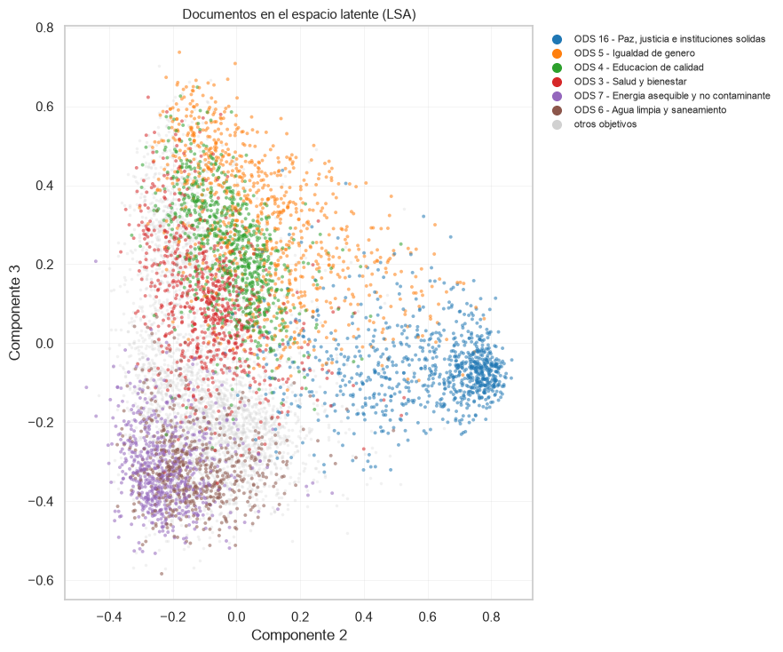

```python
# Proyeccion de los documentos sobre dos componentes latentes.
def graficar_espacio_latente(X_lsa, y, componentes=(2, 3), n_ods=6, semilla=SEMILLA):
    """Dibuja los documentos en el plano de dos componentes, coloreados por ODS.

    Parametros
    ----------
    n_ods : int
        Numero de objetivos a mostrar. Con los 16 a la vez la figura resulta
        ilegible: se toman los mas frecuentes y el resto se agrupa en "otros".
    """
    y = np.asarray(y)

    # Los componentes se nombran desde 1, igual que en la tabla de extraer_topicos.
    i, j = componentes[0] - 1, componentes[1] - 1

    destacadas = pd.Series(y).value_counts().index[:n_ods]
    destacadas = list(destacadas)

    colores_ods = dict(zip(destacadas, plt.cm.tab10.colors))
    GRIS = (0.82, 0.82, 0.82)

    colores = np.array([colores_ods.get(v, GRIS) for v in y])
    es_destacada = np.isin(y, destacadas)

    # Orden de dibujado aleatorio, para que ninguna clase tape sistematicamentem a las demas
    rng = np.random.default_rng(semilla)
    orden_fondo = np.flatnonzero(~es_destacada)
    orden_frente = rng.permutation(np.flatnonzero(es_destacada))

    fig, ax = plt.subplots(figsize=(9, 7.5))

    ax.scatter(X_lsa[orden_fondo, i], X_lsa[orden_fondo, j], c=[GRIS], s=6, alpha=0.3, linewidths=0)
    ax.scatter(X_lsa[orden_frente, i], X_lsa[orden_frente, j], c=colores[orden_frente], s=8, alpha=0.55, linewidths=0)

    ax.set_xlabel(f"Componente {componentes[0]}")
    ax.set_ylabel(f"Componente {componentes[1]}")
    ax.set_title("Documentos en el espacio latente (LSA)", fontsize=11)
    ax.grid(alpha=0.3, linewidth=0.5)

    handles = [
        Line2D([], [], marker="o", linestyle="none", markersize=7, color=colores_ods[o], label=f"ODS {o} - {NOMBRES_ODS.get(o, '?')}")
        for o in destacadas
    ]
    if (~es_destacada).any():
        handles.append(
            Line2D([], [], marker="o", linestyle="none", markersize=7, color=GRIS, label="otros objetivos")
        )

    ax.legend(handles=handles, fontsize=8, loc="upper left", bbox_to_anchor=(1.01, 1), frameon=False)

    plt.tight_layout()
    plt.show()


graficar_espacio_latente(X_lsa_topicos, y_train)
```

### Lectura del espacio latente

La figura muestra los documentos proyectados sobre las componentes 2 y 3, coloreados por objetivo. Se omite la componente 1 por la razón explicada en §3.3: recoge la dirección media del corpus y no aporta separación entre clases.

**Todos los objetivos ocupan regiones reconocibles, pero con fronteras difusas.** No se ven grupos disjuntos separados por espacio vacío, sino zonas de mayor densidad que se solapan en los bordes. Es el comportamiento esperable de un corpus temático: los textos forman un continuo, y los objetivos son regiones de ese continuo más que islas independientes.

**El ODS 16 es el mejor delimitado.** Su región es la más compacta y la que menos puntos ajenos admite. Para no quedarse en la impresión visual, se midió la **pureza del vecindario**: qué fracción de los 20 vecinos más cercanos de cada texto pertenece a su mismo objetivo.

| ODS | Pureza | Se mezcla sobre todo con |
| --- | --- | --- |
| **16** Paz, justicia e instituciones | **0,85** | 5, 3 |
| 7 Energía asequible | 0,59 | **6 (89 % de sus vecinos ajenos)** |
| 5 Igualdad de género | 0,58 | 4 |
| 3 Salud y bienestar | 0,56 | 4, 5 |
| 4 Educación de calidad | 0,52 | 5, 3 |
| 6 Agua limpia y saneamiento | 0,51 | **7 (83 %)** |

**El par 6–7 destaca sobre los demás.** Agua y energía no solo se solapan: se solapan *entre sí* de forma casi exclusiva, concentrando el 89 % y el 83 % de sus vecinos ajenos en el otro objetivo. Es comprensible infraestructura, acceso a servicios básicos, redes de distribución y sostenibilidad son vocabulario común a ambos y constituye una predicción concreta: **si el modelo confunde algún par de objetivos, el 6 y el 7 deberían encabezar la lista**.

# 4. Reducción de la dimensionalidad para la clasificación

## 4.1 Por qué reducir

- **Sobreajuste.** Con tantas dimensiones, un modelo puede encontrar combinaciones de términos que separan perfectamente el entrenamiento por puro azar y no generalizan.
- **Ruido.** Buena parte del vocabulario aparece en muy pocos documentos y aporta más variabilidad que señal, incluso después del filtro `min_df`.
- **Coste.** Algunos algoritmos —Random Forest en particular— escalan mal con el número de características.

LSA concentra la señal en unos cientos de dimensiones y, como se explicó en §3.1, además acerca documentos que hablan de lo mismo con palabras distintas. A cambio se pierde la **interpretabilidad directa**: ya no se puede decir "este texto es del ODS 6 porque contiene 'agua'", sino que la decisión se toma sobre conceptos latentes.

## 4.2 Las dos representaciones

Se construyen dos variantes del mismo pipeline, idénticas salvo por la etapa de reducción:

[output not shown]

Encapsular ambas en un `Pipeline` mantiene la garantía dentro de la validación cruzada, tanto el vocabulario como la descomposición SVD se reaprenden en cada pliegue usando solo los datos de entrenamiento de ese pliegue.

```python
# Construccion de los pipelines de clasificacion, con y sin reduccion.

def construir_pipeline_clasificacion(clasificador, representacion="lsa",
                                     n_componentes=200, semilla=SEMILLA,
                                     **parametros_texto):
    """Arma el pipeline completo: texto crudo -> prediccion de ODS.

    Parametros
    ----------
    clasificador : estimador de scikit-learn
        El modelo final del pipeline.
    representacion : {"tfidf", "lsa"}
        "tfidf" entrega la matriz dispersa directamente al clasificador.
        "lsa" intercala TruncatedSVD + Normalizer.
    n_componentes : int
        Componentes del SVD. Solo se usa si representacion == "lsa".

    Retorna
    -------
    sklearn.pipeline.Pipeline
    """

    if representacion not in {"tfidf", "lsa"}:
        raise ValueError(f"Representacion desconocida: {representacion}")

    pasos = list(construir_pipeline_texto(**parametros_texto).steps)

    if representacion == "lsa":
        pasos.append(
            ("reducir", TruncatedSVD(n_components=n_componentes, random_state=semilla))
        )

        pasos.append(("normalizar_lsa", Normalizer(copy=False)))

    pasos.append(("clasificar", clasificador))

    return Pipeline(pasos)
```

# 5. Modelo de clasificación

## 5.1 Elección de los algoritmos

Se comparan tres algoritmos que abordan el problema desde perspectivas distintas. Compararlos, en lugar de asumir uno, permite que la justificación se apoye en evidencia.

| Algoritmo | Por qué es candidato | Hiperparámetros explorados |
| --- | --- | --- |
| **SVM lineal** (`LinearSVC`) | Es el estándar en clasificación de texto. En espacios de dimensión muy alta las clases suelen ser separables linealmente, y maximizar el margen generaliza bien aunque haya pocas muestras por clase —ju… | `C`, `class_weight` |
| **Regresión logística** | Rendimiento comparable al SVM lineal, con una ventaja para este problema: **devuelve probabilidades**. Permite decir "este texto es 70 % ODS 4 y 20 % ODS 5", lo cual importa cuando muchos textos tocan… | `C`, `class_weight` |
| **Random Forest** | Contraste no lineal. Captura interacciones entre términos que los modelos lineales no ven, y sirve para responder una pregunta concreta: ¿la frontera entre objetivos es lineal o no? Si el bosque no su… | `n_estimators`, `max_depth`, `min_samples_leaf` |

## 5.2 Métricas de evaluación

La elección de métrica no es un detalle en un problema desbalanceado: determina qué modelo gana.

**Por qué no *accuracy*.** El ODS 16 concentra el 11,2 % de los textos y el ODS 12 el 3,2 %. Un modelo que clasificara bien las clases grandes e ignorara las pequeñas obtendría una exactitud aparentemente razonable mientras falla justo donde hay menos datos. La *accuracy* promedia sobre documentos, así que cada clase pesa en proporción a su tamaño.

**Por qué macro-F1.** El F1 combina precisión y exhaustividad, y el promedio **macro** lo calcula por clase y luego promedia **sin ponderar**. Así los 16 objetivos valen lo mismo y fallar en el ODS 12 cuesta exactamente igual que fallar en el ODS 16. Es la métrica que corresponde cuando todas las clases importan por igual, que es el caso: al UNFPA le interesa tanto detectar textos sobre producción responsable como sobre paz y justicia.

Se reportan además, como referencia:

| Métrica | Qué aporta |
| --- | --- |
| *Accuracy* | Comparabilidad con otros trabajos; se espera que sea superior al macro-F1 |
| *Balanced accuracy* | Exhaustividad media por clase; complementa al macro-F1 ignorando la precisión |
| F1 por clase | Dónde falla exactamente el modelo (§6.2) |

## 5.3 Estrategia de validación

La búsqueda de hiperparámetros se hace con **validación cruzada estratificada de 5 pliegues sobre el conjunto de entrenamiento**. Estratificada por la misma razón que la partición: mantener la proporción de cada objetivo en todos los pliegues, de modo que las clases minoritarias estén representadas en cada uno.

```python
# Rejillas de hiperparametros y busqueda con validacion cruzada.

REJILLAS = {
    "SVM lineal": {
        "modelo": LinearSVC(random_state=SEMILLA, max_iter=5000),
        "parametros": {
            "clasificar__C": [0.1, 1.0, 10.0],
            "clasificar__class_weight": [None, "balanced"],
        },
    },
    "Regresion logistica": {
        "modelo": LogisticRegression(random_state=SEMILLA, max_iter=2000),
        "parametros": {
            "clasificar__C": [0.1, 1.0, 10.0],
            "clasificar__class_weight": [None, "balanced"],
        },
    },
    "Random Forest": {
        "modelo": RandomForestClassifier(random_state=SEMILLA, n_jobs=-1),
        "parametros": {
            "clasificar__n_estimators": [300],
            "clasificar__max_depth": [None, 40],
            "clasificar__min_samples_leaf": [1, 3],
        },
    },
}

# Componentes del LSA a explorar. aqui el criterio es la capacidad discriminativa.
COMPONENTES_LSA = [100, 200, 300]


def buscar_hiperparametros(X_train, y_train, nombre_algoritmo, representacion,
                           n_pliegues=N_PLIEGUES, semilla=SEMILLA, verbose=1):
    """Busca la mejor configuracion de un algoritmo sobre una representacion.

    Parametros
    ----------
    nombre_algoritmo : str
        Clave de REJILLAS.
    representacion : {"tfidf", "lsa"}

    Retorna
    -------
    GridSearchCV ajustado.
    """

    if nombre_algoritmo not in REJILLAS:
        raise ValueError(f"Algoritmo desconocido: {nombre_algoritmo}")

    config = REJILLAS[nombre_algoritmo]
    modelo = clone(config["modelo"])
    parametros = dict(config["parametros"])

    pipeline = construir_pipeline_clasificacion(modelo, representacion)

    if representacion == "lsa":
        parametros["reducir__n_components"] = COMPONENTES_LSA

    cv = StratifiedKFold(n_splits=n_pliegues, shuffle=True, random_state=semilla)

    busqueda = GridSearchCV(
        pipeline,
        parametros,
        scoring="f1_macro",
        cv=cv,
        n_jobs=-1,
        verbose=verbose,
        refit=True
    )

    inicio = time.perf_counter()
    busqueda.fit(X_train, y_train)
    segundos = time.perf_counter() - inicio

    print(f"\n{nombre_algoritmo} ({representacion}): "
          f"f1_macro = {busqueda.best_score_:.3f}  ({segundos:.0f} s)")
    print(f"  {busqueda.best_params_}")

    return busqueda
```

## 5.4 Ejecución de la búsqueda

Esta es la celda más costosa del notebook: 3 algoritmos × 2 representaciones, cada uno con su rejilla y 5 pliegues de validación cruzada. Cada combinación reajusta el vectorizador y, en la variante LSA, también el SVD.

```python
# Estimacion del coste antes de lanzar la busqueda completa.

def estimar_coste(X_train, y_train, n_muestra=2000, semilla=SEMILLA):
    """Estima cuanto tardara la busqueda completa de §5.4.

    Ajusta UNA sola vez cada combinacion de algoritmo y representacion sobre
    una submuestra, y extrapola al numero real de ajustes que hara
    GridSearchCV: (configuraciones de la rejilla) x (pliegues) x (escala).

    La extrapolacion es aproximada. Ningun algoritmo escala exactamente lineal
    con el numero de documentos, y GridSearchCV reparte el trabajo entre nucleos
    con n_jobs=-1, asi que el tiempo real sera menor que la suma de los ajustes.
    Sirve para decidir si conviene recortar alguna rejilla, no para predecir el
    tiempo exacto.

    Retorna
    -------
    pd.DataFrame
        Una fila por combinacion, con el tiempo de un ajuste y la estimacion.
    """
    Xs = X_train.iloc[:n_muestra]
    ys = y_train.iloc[:n_muestra]
    escala = len(X_train) / len(Xs)

    filas = []

    for representacion in ("tfidf", "lsa"):
        for nombre, config in REJILLAS.items():

            # Numero de combinaciones que recorrera la rejilla.
            n_config = 1
            for valores in config["parametros"].values():
                n_config *= len(valores)
            if representacion == "lsa":
                n_config *= len(COMPONENTES_LSA)

            pipeline = construir_pipeline_clasificacion(
                clone(config["modelo"]), representacion
            )

            inicio = time.perf_counter()
            pipeline.fit(Xs, ys)
            un_ajuste = time.perf_counter() - inicio

            # GridSearchCV ajusta n_config x n_pliegues veces, mas el refit final.
            ajustes = n_config * N_PLIEGUES + 1
            filas.append({
                "algoritmo": nombre,
                "representacion": representacion,
                "configuraciones": n_config,
                "ajustes": ajustes,
                "un_ajuste_s": un_ajuste,
                "estimado_s": un_ajuste * ajustes * escala,
            })

            print(f"  {nombre:20s} {representacion:5s}  "
                  f"1 ajuste = {un_ajuste:5.1f}s x {ajustes:3d} ajustes "
                  f"-> ~{un_ajuste * ajustes * escala / 60:5.1f} min", flush=True)

    return pd.DataFrame(filas)


print(f"Midiendo sobre una submuestra (escala x{len(X_train) / 2000:.1f}):\n")
coste = estimar_coste(X_train, y_train)

total_min = coste["estimado_s"].sum() / 60
print(f"\nEstimacion secuencial total: ~{total_min:.0f} min")
print(f"Con n_jobs=-1 sobre {os.cpu_count()} nucleos, el tiempo real sera bastante menor.")

mas_lenta = coste.loc[coste["estimado_s"].idxmax()]
print(f"\nCombinacion mas costosa: {mas_lenta['algoritmo']} sobre "
      f"{mas_lenta['representacion']} (~{mas_lenta['estimado_s'] / 60:.0f} min, "
      f"{mas_lenta['estimado_s'] / coste['estimado_s'].sum():.0%} del total)")

display(coste.round(2))
```

```
Midiendo sobre una submuestra (escala x3.9):

  SVM lineal           tfidf  1 ajuste =   0.5s x  31 ajustes -> ~  1.1 min
  Regresion logistica  tfidf  1 ajuste =   0.6s x  31 ajustes -> ~  1.2 min
  Random Forest        tfidf  1 ajuste =   0.6s x  21 ajustes -> ~  0.8 min
  SVM lineal           lsa    1 ajuste =   0.8s x  91 ajustes -> ~  4.4 min
  Regresion logistica  lsa    1 ajuste =   0.6s x  91 ajustes -> ~  3.7 min
  Random Forest        lsa    1 ajuste =   0.8s x  61 ajustes -> ~  3.1 min

Estimacion secuencial total: ~14 min
Con n_jobs=-1 sobre 10 nucleos, el tiempo real sera bastante menor.

Combinacion mas costosa: SVM lineal sobre lsa (~4 min, 31% del total)
```

|  | algoritmo | representacion | configuraciones | ajustes | un_ajuste_s | estimado_s |
| --- | --- | --- | --- | --- | --- | --- |
| 0 | SVM lineal | tfidf | 6 | 31 | 0.54 | 64.66 |
| 1 | Regresion logistica | tfidf | 6 | 31 | 0.59 | 71.14 |
| 2 | Random Forest | tfidf | 4 | 21 | 0.61 | 49.43 |
| 3 | SVM lineal | lsa | 18 | 91 | 0.75 | 264.45 |
| 4 | Regresion logistica | lsa | 18 | 91 | 0.62 | 219.48 |
| 5 | Random Forest | lsa | 12 | 61 | 0.80 | 187.85 |

```python
# Busqueda completa: 3 algoritmos x 2 representaciones.

busquedas = {}
inicio_total = time.perf_counter()

for representacion in ("tfidf", "lsa"):
    for nombre in REJILLAS:
        clave = f"{nombre} | {representacion}"
        print(f"\n=== {clave} ===", flush=True)

        busquedas[clave] = buscar_hiperparametros(
            X_train, y_train, nombre, representacion
        )

print(f"\nTiempo total de la busqueda: {time.perf_counter() - inicio_total:.0f} s")
```

```
=== SVM lineal | tfidf ===
Fitting 5 folds for each of 6 candidates, totalling 30 fits

SVM lineal (tfidf): f1_macro = 0.872  (15 s)
  {'clasificar__C': 1.0, 'clasificar__class_weight': None}

=== Regresion logistica | tfidf ===
Fitting 5 folds for each of 6 candidates, totalling 30 fits

Regresion logistica (tfidf): f1_macro = 0.871  (16 s)
  {'clasificar__C': 10.0, 'clasificar__class_weight': None}

=== Random Forest | tfidf ===
Fitting 5 folds for each of 4 candidates, totalling 20 fits
```

```
Random Forest (tfidf): f1_macro = 0.809  (20 s)
  {'clasificar__max_depth': None, 'clasificar__min_samples_leaf': 1, 'clasificar__n_estimators': 300}

=== SVM lineal | lsa ===
Fitting 5 folds for each of 18 candidates, totalling 90 fits
```

```
SVM lineal (lsa): f1_macro = 0.852  (67 s)
  {'clasificar__C': 0.1, 'clasificar__class_weight': 'balanced', 'reducir__n_components': 300}

=== Regresion logistica | lsa ===
Fitting 5 folds for each of 18 candidates, totalling 90 fits

Regresion logistica (lsa): f1_macro = 0.849  (47 s)
  {'clasificar__C': 1.0, 'clasificar__class_weight': None, 'reducir__n_components': 300}

=== Random Forest | lsa ===
Fitting 5 folds for each of 12 candidates, totalling 60 fits
```

```
Random Forest (lsa): f1_macro = 0.794  (135 s)
  {'clasificar__max_depth': None, 'clasificar__min_samples_leaf': 1, 'clasificar__n_estimators': 300, 'reducir__n_components': 100}

Tiempo total de la busqueda: 301 s
```

## 5.5 Comparación: TF-IDF crudo frente a LSA

La tabla siguiente es la evidencia central de esta sección. Recoge las seis combinaciones con su macro-F1 en validación cruzada, la desviación entre pliegues y el tiempo de ajuste.

La desviación importa tanto como la media: una diferencia de rendimiento menor que la variabilidad entre pliegues no es una diferencia real, y conviene no presentarla como tal.

|  | algoritmo | representacion | f1_macro_cv | desviacion | n_componentes | mejores_parametros | segundos | n_configuraciones |
| --- | --- | --- | --- | --- | --- | --- | --- | --- |
| 0 | SVM lineal | tfidf | 0.871989 | 0.009400 | NaN | {'C': 1.0, 'class_weight': None} | 2.202951 | 6 |
| 1 | Regresion logistica | tfidf | 0.871205 | 0.010343 | NaN | {'C': 10.0, 'class_weight': None} | 2.845309 | 6 |
| 2 | SVM lineal | lsa | 0.852046 | 0.007388 | 300.0 | {'C': 0.1, 'class_weight': 'balanced'} | 4.376846 | 18 |
| 3 | Regresion logistica | lsa | 0.849201 | 0.008148 | 300.0 | {'C': 1.0, 'class_weight': None} | 3.056990 | 18 |
| 4 | Random Forest | tfidf | 0.808689 | 0.007589 | NaN | {'max_depth': None, 'min_samples_leaf': 1, 'n_... | 3.142429 | 4 |
| 5 | Random Forest | lsa | 0.794017 | 0.007707 | 100.0 | {'max_depth': None, 'min_samples_leaf': 1, 'n_... | 4.043959 | 12 |

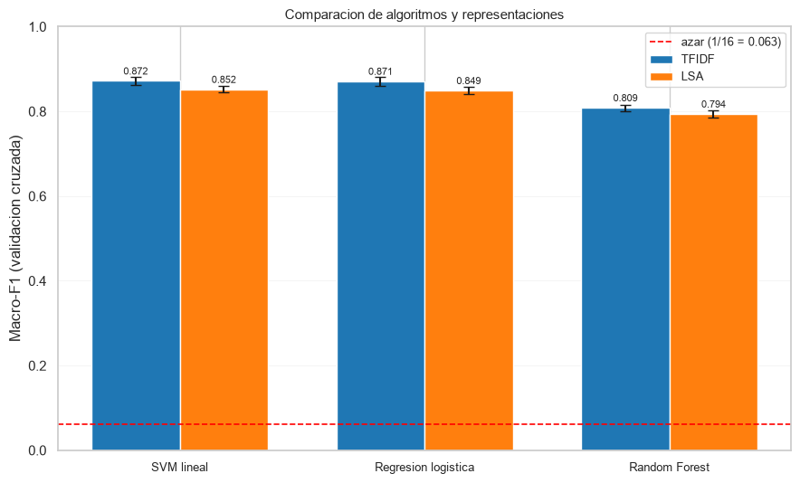

```python
# Tabla y grafico comparativos de las seis combinaciones.

def comparar_busquedas(busquedas):
    """Consolida los resultados de todas las busquedas en una tabla.

    Retorna
    -------
    pd.DataFrame
        algoritmo, representacion, f1_macro_cv, desviacion, n_componentes,
        mejores_parametros y segundos; ordenado por f1_macro_cv.
    """

    filas = []

    for clave, busqueda in busquedas.items():
        algoritmo, representacion = [p.strip() for p in clave.split("|")]
        resultados = busqueda.cv_results_
        i = busqueda.best_index_

        parametros = dict(busqueda.best_params_)
        n_componentes = parametros.pop("reducir__n_components", None)

        filas.append({
            "algoritmo": algoritmo,
            "representacion": representacion,
            "f1_macro_cv": busqueda.best_score_,
            "desviacion": resultados["std_test_score"][i],
            "n_componentes": n_componentes,
            "mejores_parametros": {k.replace("clasificar__", ""): v for k, v in parametros.items()},
            "segundos": busqueda.refit_time_,
            "n_configuraciones": len(resultados["params"])
        })

    return (
        pd.DataFrame(filas)
        .sort_values("f1_macro_cv", ascending=False)
        .reset_index(drop=True)
    )


comparacion = comparar_busquedas(busquedas)
display(comparacion)

algoritmos = list(dict.fromkeys(comparacion["algoritmo"]))
representaciones = ["tfidf", "lsa"]
colores = {"tfidf": "tab:blue", "lsa": "tab:orange"}

x = np.arange(len(algoritmos))
ancho = 0.36

fig, ax = plt.subplots(figsize=(9, 5.5))

for i, rep in enumerate(representaciones):
    sub = comparacion.set_index(["algoritmo", "representacion"])
    alturas, errores = [], []

    for alg in algoritmos:
        if (alg, rep) in sub.index:
            alturas.append(sub.loc[(alg, rep), "f1_macro_cv"])
            errores.append(sub.loc[(alg, rep), "desviacion"])
        else:
            alturas.append(np.nan)
            errores.append(np.nan)

    posiciones = x + (i - 0.5) * ancho
    ax.bar(posiciones, alturas, ancho, yerr=errores, capsize=4, color=colores[rep], label=rep.upper())

    for pos, h in zip(posiciones, alturas):
        if not np.isnan(h):
            ax.text(pos, h + 0.015, f"{h:.3f}", ha="center", fontsize=8)

ax.axhline(0.0625, color="red", linestyle="--", linewidth=1.2, label="azar (1/16 = 0.063)")

ax.set_xticks(x)
ax.set_xticklabels(algoritmos, fontsize=9)
ax.set_ylabel("Macro-F1 (validacion cruzada)")
ax.set_title("Comparacion de algoritmos y representaciones", fontsize=11)
ax.set_ylim(0, min(1.0, comparacion["f1_macro_cv"].max() * 1.25))
ax.legend(fontsize=9)
ax.grid(axis="y", alpha=0.3, linewidth=0.5)

plt.tight_layout()
plt.show()
```

### Resultado de la comparación

**TF-IDF crudo supera a LSA en los tres algoritmos**, y esa consistencia importa más que la magnitud: 0,872 frente a 0,852 en el SVM, 0,871 frente a 0,849 en la regresión logística y 0,809 frente a 0,794 en Random Forest. La ventaja ronda los 2 puntos de macro-F1, algo más del doble de la desviación entre pliegues, así que no es ruido. Que se repita en los tres apunta a una propiedad del problema y no a una casualidad de un modelo concreto.

**Los hiperparámetros elegidos refuerzan esa lectura.** Los dos modelos lineales sobre LSA seleccionaron **300 componentes, el máximo disponible en la rejilla**. Que el óptimo caiga en el extremo superior indica que el techo estaba limitando: con más componentes probablemente habrían mejorado, acercándose al rendimiento de TF-IDF sin llegar a superarlo. Random Forest hizo lo contrario y se quedó con **100, el mínimo**, coherente con que los árboles se degradan al aumentar la dimensionalidad.

**Entre los dos modelos lineales hay un empate técnico.** El SVM obtuvo 0,87199 y la regresión logística 0,87121: una diferencia de **0,0008**, más de diez veces menor que la desviación entre pliegues.

**Random Forest queda claramente por detrás**, unos 6 puntos por debajo de los lineales en ambas representaciones. Conviene descartar una explicación intuitiva pero incorrecta: no se debe a que maneje mal el problema multiclase. Es justo al revés — Random Forest es el único de los tres **multiclase nativo**, ya que cada hoja vota sobre las 16 clases a la vez, mientras que `LinearSVC` y `LogisticRegression` descomponen el problema en 16 clasificadores binarios uno-contra-resto.

La causa está en la naturaleza de los datos. Un árbol clasifica mediante cortes sucesivos sobre variables individuales, los modelos lineales en cambio, **combinan todas las variables a la vez** con un vector de pesos, que es la forma natural de aprovechar evidencia repartida entre miles de términos poco frecuentes.

Este resultado responde además a la pregunta implícita al elegir los algoritmos **la frontera entre objetivos es esencialmente lineal**. El modelo no lineal no encontró estructura adicional que aprovechar, lo cual es el comportamiento habitual en clasificación de texto y la razón por la que el SVM lineal sigue siendo el estándar.

## 5.6 Selección del modelo final

El criterio se fija **antes** de ver los resultados, para que la elección no se acomode a ellos:

> Gana la combinación con **mayor macro-F1 en validación cruzada**. Si dos quedan dentro de una desviación típica, se prefiere la **más simple y rápida**, por ser preferible en despliegue a igualdad de rendimiento.

La regla de desempate no es cosmética: si TF-IDF y LSA empatan, elegir LSA reduce el modelo de decenas de miles de dimensiones a unos cientos, lo que abarata cualquier uso posterior.

```python
# Seleccion del modelo final segun el criterio declarado en §5.6.

def seleccionar_modelo(comparacion, busquedas):
    """Aplica el criterio de §5.6 y devuelve el pipeline ganador ya ajustado.

    Retorna
    -------
    nombre : str      clave de la combinacion ganadora
    modelo : Pipeline el mejor estimador, reajustado sobre todo el entrenamiento
    fila : pd.Series  su fila de la tabla comparativa
    """

    mejor = comparacion.loc[comparacion["f1_macro_cv"].idxmax()]
    umbral = mejor["f1_macro_cv"] - mejor["desviacion"]

    empatados = comparacion[comparacion["f1_macro_cv"] >= umbral]

    if len(empatados) > 1:
        fila = empatados.loc[empatados["segundos"].idxmin()]
        print(f"{len(empatados)} combinaciones dentro de una desviacion "
              f"({umbral:.3f}) del mejor macro-F1 ({mejor['f1_macro_cv']:.3f}).")
        print("Se desempata por coste computacional:")

        display(
            empatados[["algoritmo",
                       "representacion",
                       "f1_macro_cv",
                       "desviacion",
                       "segundos"]].sort_values("segundos")
        )
    else:
        fila = mejor

    clave = f"{fila['algoritmo']} | {fila['representacion']}"
    modelo = busquedas[clave].best_estimator_

    print(f"\nModelo seleccionado: {clave}")
    print(f"  macro-F1 en validacion cruzada: {fila['f1_macro_cv']:.3f} "
          f"± {fila['desviacion']:.3f}")
    print(f"  parametros: {fila['mejores_parametros']}")
    if pd.notna(fila["n_componentes"]):
        print(f"  componentes LSA: {int(fila['n_componentes'])}")

    return clave, modelo, fila


nombre_modelo, modelo_final, fila_ganadora = seleccionar_modelo(comparacion, busquedas)
```

```
2 combinaciones dentro de una desviacion (0.863) del mejor macro-F1 (0.872).
Se desempata por coste computacional:
```

|  | algoritmo | representacion | f1_macro_cv | desviacion | segundos |
| --- | --- | --- | --- | --- | --- |
| 0 | SVM lineal | tfidf | 0.871989 | 0.009400 | 2.202951 |
| 1 | Regresion logistica | tfidf | 0.871205 | 0.010343 | 2.845309 |

```
Modelo seleccionado: SVM lineal | tfidf
  macro-F1 en validacion cruzada: 0.872 ± 0.009
  parametros: {'C': 1.0, 'class_weight': None}
```